# Aprendizaje supervisado

En las experimentaciones anteriores se han utilizado tres algoritmos distintos para aprendizaje supervisado (árbol de decisión, Xgboost y SVM). El hecho de que las clases de clasificación estén muy desbalanceadas hace que los modelos generados no clasifiquen como se espera.

Así, en este notebook se trabaja con los predictores y la clases Y1(ser nodo aislado) e Y2 (estar en NCG), intentando solventar el problema del desbalance.

En primer lugar se cargan las librerías necesarias.

```r
library(dplyr)
library(igraph)
library(readxl)
library(rpart)
library(rpart.plot)
library(e1071)
library(xgboost)
library(caret)
```

Cargo el dataframe

```r
grafodf <- read.table("./grafodf.txt", header = TRUE, sep = ",")
```

Cambio los nombres de las columnas para facilitar la aplicación de los algoritmos.

```r
colnames(grafodf) <- c("ID","NODOS", "X1","X2", "X3", "X4", "Y1", "Y2" )
```

Como puede verse en el histograma, las clases de clasificación están muy desbalanceadas.

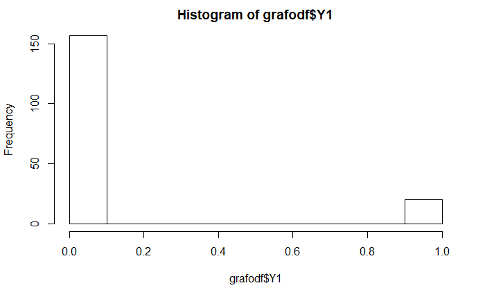

```r
hist(grafodf$Y1)
```

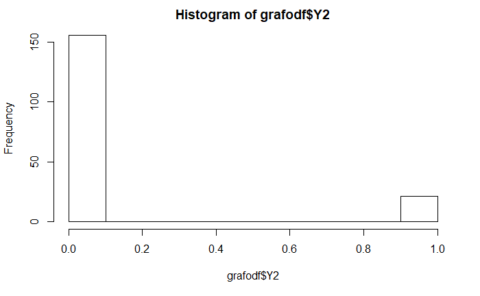

```r
hist(grafodf$Y2)
```

Para aplicar el algoritmo, es necesario que las variables de respuesta sean factores.

```r
grafodf$Y1 <- as.factor(grafodf$Y1)
grafodf$Y2 <- as.factor(grafodf$Y2)
```

Me quedo con los predictores y la etiqueta Y2.

```r
df1 <- grafodf[, 3:7]
df2 <- select(grafodf,3,4,5,6, 8)
```

Divido en datos de entrenamiento y prueba.

```r
set.seed(1)
trainIndex1 <- createDataPartition(df1$Y1, p = .75,
                                  list = FALSE)
trainY1 <- df1[ trainIndex1,]
testY1  <- df1[-trainIndex1,]

trainIndex2 <- createDataPartition(df2$Y2, p = .75,
                                  list = FALSE)
trainY2 <- df2[ trainIndex2,]
testY2  <- df2[-trainIndex2,]
```

Para evitar el desbalance, hay dos opciones: “quitar” ejemplos de la clase 0 (no estar en NCG) para que haya una cantidad similar a la clase 1, o estimar nuevos ejemplos que se cataloguen como 1 para compensar. Esto último es lo que haremos, ya que de lo contrario estaríamos perdiendo mucha información.

```r
set.seed(9560)
up_train1 <- upSample(x = trainY1[, -ncol(trainY1)],
                     y = trainY1$Y1)
table(up_train1$Class)
```

```
  0   1
118 118
```

```r
head(up_train1)
```

|  | X1 | X2 | X3 | X4 | Class |
| --- | --- | --- | --- | --- | --- |
| 1 | 0.5875 | 0.2779780 | 0.9844992 | 0.04684630 | 0 |
| 2 | 0.5500 | 0.1870035 | 0.9860939 | 0.37339253 | 0 |
| 3 | 0.5500 | 0.2773834 | 0.9851365 | 0.04776485 | 0 |
| 4 | 0.5500 | 0.2130654 | 0.9857746 | 0.54516228 | 0 |
| 5 | 0.9375 | 0.9767167 | 0.9977125 | 0.00000000 | 0 |
| 6 | 0.4500 | 0.2146015 | 0.9864134 | 0.10379669 | 0 |

```r
up_train2 <- upSample(x = trainY2[, -ncol(trainY2)],
                     y = trainY2$Y2)
table(up_train2$Class)
```

```
  0   1
117 117
```

```r
head(up_train2)
```

|  | X1 | X2 | X3 | X4 | Class |
| --- | --- | --- | --- | --- | --- |
| 1 | 0.5500 | 0.2773834 | 0.9851365 | 0.04776485 | 0 |
| 2 | 0.4500 | 0.1554100 | 0.9825916 | 0.06965707 | 0 |
| 3 | 0.4500 | 0.2146015 | 0.9864134 | 0.10379669 | 0 |
| 4 | 0.4375 | 0.4778779 | 0.9769080 | 0.00000000 | 0 |
| 5 | 0.5750 | 0.6494479 | 0.9800583 | 0.00000000 | 0 |
| 6 | 0.0000 | 0.0000000 | 0.0000000 | 0.00000000 | 0 |

Representamos gráficamente los histogramas para ver la distribución de las clases.

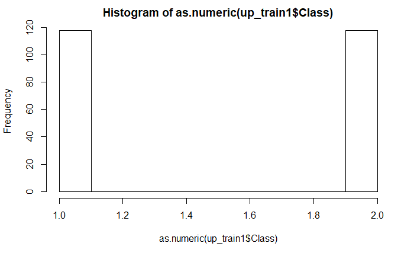

```r
hist(as.numeric(up_train1$Class))
```

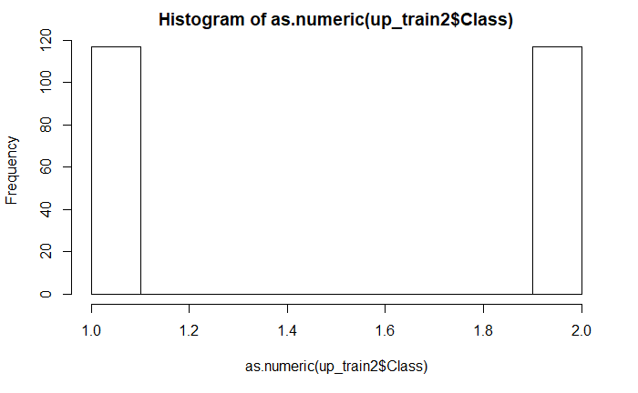

```r
hist(as.numeric(up_train2$Class))
```

Con esto tenemos un conjunto de entrenamiento balanceado totalmente. Entrenamos los modelos y evaluamos.

- Árbol de decisión

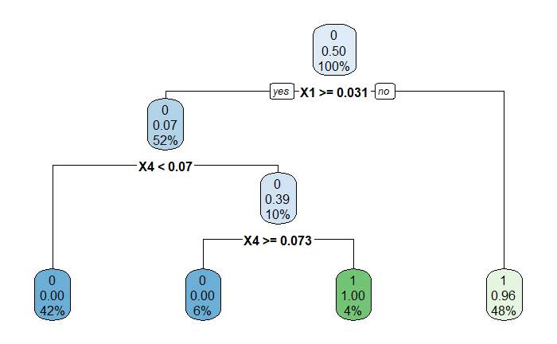

```r
arbol1 <- rpart(Class~., data = up_train1, method = 'class')
rpart.plot(arbol1)
```

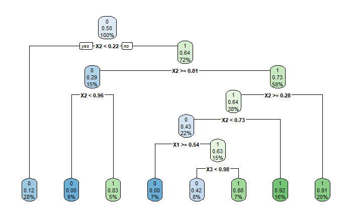

```r
arbol2 <- rpart(Class~., data = up_train2, method = 'class')
rpart.plot(arbol2)
```

Evaluamos los modelos: - Etiqueta Y1.

```r
pred_arbol <- predict(arbol1, testY1, type = 'class')
confusionMatrix(table(pred_arbol, testY1$Y1))
```

```
Confusion Matrix and Statistics


pred_arbol  0  1
         0 35  0
         1  4  5

               Accuracy : 0.9091
                 95% CI : (0.7833, 0.9747)
    No Information Rate : 0.8864
    P-Value [Acc > NIR] : 0.4298

                  Kappa : 0.6654

 Mcnemar's Test P-Value : 0.1336

            Sensitivity : 0.8974
            Specificity : 1.0000
         Pos Pred Value : 1.0000
         Neg Pred Value : 0.5556
             Prevalence : 0.8864
         Detection Rate : 0.7955
   Detection Prevalence : 0.7955
      Balanced Accuracy : 0.9487

       'Positive' Class : 0
```

- Etiqueta Y2.

```r
pred_arbol <- predict(arbol2, testY2, type = 'class')
confusionMatrix(table(pred_arbol, testY2$Y2))
```

```
Confusion Matrix and Statistics


pred_arbol  0  1
         0 33  3
         1  6  2

               Accuracy : 0.7955
                 95% CI : (0.647, 0.902)
    No Information Rate : 0.8864
    P-Value [Acc > NIR] : 0.9765

                  Kappa : 0.1951

 Mcnemar's Test P-Value : 0.5050

            Sensitivity : 0.8462
            Specificity : 0.4000
         Pos Pred Value : 0.9167
         Neg Pred Value : 0.2500
             Prevalence : 0.8864
         Detection Rate : 0.7500
   Detection Prevalence : 0.8182
      Balanced Accuracy : 0.6231

       'Positive' Class : 0
```

Esto con los ajustes por defecto, ahora optimizamos el parámetro CP y entrenamos con k-CV, k =10.

```r
control_class <- trainControl(
  method = "cv",
  number = 10
)

cps = seq(0 , 1, by=0.05)
arbol11 <- train (Class ~ ., up_train1,
                 tuneGrid = expand.grid(cp = cps),
                 method="rpart",
                 trControl=control_class)
print(arbol11)
```

```
CART

236 samples
  4 predictor
  2 classes: '0', '1'

No pre-processing
Resampling: Cross-Validated (10 fold)
Summary of sample sizes: 212, 212, 212, 212, 213, 213, ...
Resampling results across tuning parameters:

  cp    Accuracy   Kappa
  0.00  0.9663043  0.9325755
  0.05  0.9452899  0.8905629
  0.10  0.9452899  0.8905629
  0.15  0.9452899  0.8905629
  0.20  0.9452899  0.8905629
  0.25  0.9452899  0.8905629
  0.30  0.9452899  0.8905629
  0.35  0.9452899  0.8905629
  0.40  0.9452899  0.8905629
  0.45  0.9452899  0.8905629
  0.50  0.9452899  0.8905629
  0.55  0.9452899  0.8905629
  0.60  0.9452899  0.8905629
  0.65  0.9452899  0.8905629
  0.70  0.9452899  0.8905629
  0.75  0.9452899  0.8905629
  0.80  0.9452899  0.8905629
  0.85  0.9452899  0.8905629
  0.90  0.5288043  0.0750000
  0.95  0.4913043  0.0000000
  1.00  0.4913043  0.0000000

Accuracy was used to select the optimal model using the largest value.
The final value used for the model was cp = 0.
```

```r
arbol22 <- train (Class ~ ., up_train2,
                 tuneGrid = expand.grid(cp = cps),
                 method="rpart",
                 trControl=control_class)
print(arbol22)
```

```
CART

234 samples
  4 predictor
  2 classes: '0', '1'

No pre-processing
Resampling: Cross-Validated (10 fold)
Summary of sample sizes: 210, 210, 210, 210, 211, 211, ...
Resampling results across tuning parameters:

  cp    Accuracy   Kappa
  0.00  0.8285408  0.656418909
  0.05  0.7810771  0.561152946
  0.10  0.7301713  0.459433107
  0.15  0.7091568  0.416273912
  0.20  0.7091568  0.416273912
  0.25  0.7091568  0.416273912
  0.30  0.7091568  0.416273912
  0.35  0.7091568  0.416273912
  0.40  0.6799901  0.357940579
  0.45  0.4956522  0.002316602
  0.50  0.4913043  0.000000000
  0.55  0.4913043  0.000000000
  0.60  0.4913043  0.000000000
  0.65  0.4913043  0.000000000
  0.70  0.4913043  0.000000000
  0.75  0.4913043  0.000000000
  0.80  0.4913043  0.000000000
  0.85  0.4913043  0.000000000
  0.90  0.4913043  0.000000000
  0.95  0.4913043  0.000000000
  1.00  0.4913043  0.000000000

Accuracy was used to select the optimal model using the largest value.
The final value used for the model was cp = 0.
```

Predecimos y evaluamos. - Etiqueta Y1.

```r
pred_arbol1 <- predict(arbol11, testY1)
confusionMatrix(table(pred_arbol1, testY1$Y1))
```

```
Confusion Matrix and Statistics


pred_arbol1  0  1
          0 35  0
          1  4  5

               Accuracy : 0.9091
                 95% CI : (0.7833, 0.9747)
    No Information Rate : 0.8864
    P-Value [Acc > NIR] : 0.4298

                  Kappa : 0.6654

 Mcnemar's Test P-Value : 0.1336

            Sensitivity : 0.8974
            Specificity : 1.0000
         Pos Pred Value : 1.0000
         Neg Pred Value : 0.5556
             Prevalence : 0.8864
         Detection Rate : 0.7955
   Detection Prevalence : 0.7955
      Balanced Accuracy : 0.9487

       'Positive' Class : 0
```

- Etiqueta Y2.

```r
pred_arbol2 <- predict(arbol22, testY2)
confusionMatrix(table(pred_arbol2, testY2$Y2))
```

```
Confusion Matrix and Statistics


pred_arbol2  0  1
          0 33  3
          1  6  2

               Accuracy : 0.7955
                 95% CI : (0.647, 0.902)
    No Information Rate : 0.8864
    P-Value [Acc > NIR] : 0.9765

                  Kappa : 0.1951

 Mcnemar's Test P-Value : 0.5050

            Sensitivity : 0.8462
            Specificity : 0.4000
         Pos Pred Value : 0.9167
         Neg Pred Value : 0.2500
             Prevalence : 0.8864
         Detection Rate : 0.7500
   Detection Prevalence : 0.8182
      Balanced Accuracy : 0.6231

       'Positive' Class : 0
```

- SVM. Entreno los modelos.

```r
modelo_svm1 <- svm(formula = Class ~ ., data = up_train1, kernel = "linear",
                   scale = FALSE)
modelo_svm2 <- svm(formula = Class ~ ., data = up_train2, kernel = "linear",
                   scale = FALSE)
```

Predecimos y evaluamos. - Etiqueta Y1.

```r
pred <- predict(modelo_svm1, testY1, type = 'class')
confusionMatrix(table(pred, testY1$Y1))
```

```
Confusion Matrix and Statistics


pred  0  1
   0 39  0
   1  0  5

               Accuracy : 1
                 95% CI : (0.9196, 1)
    No Information Rate : 0.8864
    P-Value [Acc > NIR] : 0.004954

                  Kappa : 1

 Mcnemar's Test P-Value : NA

            Sensitivity : 1.0000
            Specificity : 1.0000
         Pos Pred Value : 1.0000
         Neg Pred Value : 1.0000
             Prevalence : 0.8864
         Detection Rate : 0.8864
   Detection Prevalence : 0.8864
      Balanced Accuracy : 1.0000

       'Positive' Class : 0
```

- Etiqueta Y2.

```r
pred <- predict(modelo_svm2, testY2, type = 'class')
confusionMatrix(table(pred, testY2$Y2))
```

```
Confusion Matrix and Statistics


pred  0  1
   0  7  0
   1 32  5

               Accuracy : 0.2727
                 95% CI : (0.1496, 0.4279)
    No Information Rate : 0.8864
    P-Value [Acc > NIR] : 1

                  Kappa : 0.0474

 Mcnemar's Test P-Value : 4.251e-08

            Sensitivity : 0.1795
            Specificity : 1.0000
         Pos Pred Value : 1.0000
         Neg Pred Value : 0.1351
             Prevalence : 0.8864
         Detection Rate : 0.1591
   Detection Prevalence : 0.1591
      Balanced Accuracy : 0.5897

       'Positive' Class : 0
```

Optimizamos los parámetros.

```r
costs = seq(1 , 100, by=10)
svm1 <- train (Class ~ ., up_train1,
                 tuneGrid = expand.grid(cost = costs),
                 method="svmLinear2",
                 trControl=control_class)
print(svm1)
```

```
Support Vector Machines with Linear Kernel

236 samples
  4 predictor
  2 classes: '0', '1'

No pre-processing
Resampling: Cross-Validated (10 fold)
Summary of sample sizes: 212, 213, 212, 212, 212, 212, ...
Resampling results across tuning parameters:

  cost  Accuracy   Kappa
   1    0.9317029  0.8630149
  11    0.9317029  0.8630149
  21    0.9317029  0.8630149
  31    0.9317029  0.8630149
  41    0.9317029  0.8630149
  51    0.9317029  0.8630149
  61    0.9317029  0.8630149
  71    0.9317029  0.8630149
  81    0.9317029  0.8630149
  91    0.9317029  0.8630149

Accuracy was used to select the optimal model using the largest value.
The final value used for the model was cost = 1.
```

```r
svm2 <- train (Class ~ ., up_train2,
                 tuneGrid = expand.grid(cost = costs),
                 method="svmLinear2",
                 trControl=control_class)
print(svm2)
```

```
Support Vector Machines with Linear Kernel

234 samples
  4 predictor
  2 classes: '0', '1'

No pre-processing
Resampling: Cross-Validated (10 fold)
Summary of sample sizes: 211, 211, 210, 211, 211, 210, ...
Resampling results across tuning parameters:

  cost  Accuracy   Kappa
   1    0.6039855  0.2077632
  11    0.6586957  0.3179721
  21    0.6630435  0.3267088
  31    0.6628623  0.3272340
  41    0.6543478  0.3088923
  51    0.6456522  0.2907914
  61    0.6456522  0.2909348
  71    0.6543478  0.3091757
  81    0.6585145  0.3175090
  91    0.6672101  0.3349110

Accuracy was used to select the optimal model using the largest value.
The final value used for the model was cost = 91.
```

Evalúo con el modelo óptimo. - Etiqueta Y1.

```r
pred1 <- predict(svm1, testY1)
confusionMatrix(table(pred1, testY1$Y1))
```

```
Confusion Matrix and Statistics


pred1  0  1
    0 39  0
    1  0  5

               Accuracy : 1
                 95% CI : (0.9196, 1)
    No Information Rate : 0.8864
    P-Value [Acc > NIR] : 0.004954

                  Kappa : 1

 Mcnemar's Test P-Value : NA

            Sensitivity : 1.0000
            Specificity : 1.0000
         Pos Pred Value : 1.0000
         Neg Pred Value : 1.0000
             Prevalence : 0.8864
         Detection Rate : 0.8864
   Detection Prevalence : 0.8864
      Balanced Accuracy : 1.0000

       'Positive' Class : 0
```

- Etiqueta Y2.

```r
pred2 <- predict(svm2, testY2)
confusionMatrix(table(pred2, testY2$Y2))
```

```
Confusion Matrix and Statistics


pred2  0  1
    0 18  1
    1 21  4

               Accuracy : 0.5
                 95% CI : (0.3456, 0.6544)
    No Information Rate : 0.8864
    P-Value [Acc > NIR] : 1

                  Kappa : 0.0953

 Mcnemar's Test P-Value : 5.104e-05

            Sensitivity : 0.4615
            Specificity : 0.8000
         Pos Pred Value : 0.9474
         Neg Pred Value : 0.1600
             Prevalence : 0.8864
         Detection Rate : 0.4091
   Detection Prevalence : 0.4318
      Balanced Accuracy : 0.6308

       'Positive' Class : 0
```

Se mejoran las predicciones con la optimización.

En general, el desempeño de los modelos ha mejorado al estar la clase de entrenamiento balanceada.